[figure not shown]

# CUNEF - Colegio Universitario De Estudios Financieros

## Trabajo Final en Grupo de Machine Learning

## Lending Club

### Machine Learning

- *Marta Ruedas y Lucía Piqueras*
- *Noviembre y diciembre 2020*

#### ¿Necesitas un préstamo?

#### Tu única posibilidad es convencer a un algoritmo

- 1. Introducción y objetivo
- 2. Librerías y carga de los datos
- 3. Variable Target
- 4. Filtrado de variables
  - 4.1 Tratamiento de los varlores ausentes
- 5. Análisis Exploratorio de las variables
  - 5.1 addr_state
  - 5.2 annual_inc
  - 5.3 application_type
  - 5.4 dti
  - 5.5 emp_length
  - 5.6 grade & sub-grade
  - 5.7 home_ownership
  - 5.8 initial_list_status
  - 5.9 installment
  - 5.10 int_rate
  - 5.11 loan_amnt
  - 5.12 mort_acc
  - 5.13 open_acc
  - 5.14 pub_rec_bankruptcies
  - 5.15 purpose
  - 5.16 revol_bal
  - 5.17 revol_util
  - 5.18 term
  - 5.19 total_acc
  - 5.20 verification_status
  - 5.21 Matriz_de_correlación
- 6. Guardamos el csv tras las modificaciones

## Introducción y objetivo

Partiendo de los datos recogidos en 4 ficheros con información sobre préstamos de diferentes individuos, se procederá a unicarlos todos bajo un dataframe único con el que poder trabajar. Para conseguir el objetivo que nos proponemos, deberemos limpiar todos los datos de los que disponemos, teniendo que seleccionar qué variables son importantes para nuestro objetivo y cuáles desecharemos. Tendremos que realizar toda una serie de pasos hasta quedarnos con los datos que verdaderamente nos sean útiles.

El presente trabajo nace con el objetivo de conseguir un método de predicción eficaz para saber si un cliente de una entidad financiera terminará siendo imapagador de un préstamo concedido, es decir, desarrollar un método que nos diga si debemos o no conceder un préstamo a un individuo que nos lo solicite, como entidad financiera prestamista.

Para un banco es crucial dar pasos sobre seguro y no arriesgarse con individuos que no podrán cumplir con un contrato de préstamo. Por ello, desde hace tiempo incorporan algoritmos y diferentes modelo predictivos para conseguir mantenerse a salvo.

## Librerías y carga de los datos

A continuación cargaremos las librerías que necesitaremos a lo largo del trabajo. Las volveremos a cargar en los notebooks correspondientes.

```python
import numpy as np
import pandas as pd
import matplotlib
from matplotlib import pyplot as plt
import seaborn as sns
```

Cargamos los 4 ficheros `.csv` que tenemos con la información para el training y más tarde los concatenamos para unificarlo en un solo fichero.

```python
loan = pd.read_csv("../data/raw/Loan_training_set_1_4.csv", delimiter =",", header = 1)
loan
```

|  | id | member_id | loan_amnt | funded_amnt | funded_amnt_inv | term | int_rate | installment | grade | sub_grade | ... | hardship_payoff_balance_amount | hardship_last_payment_amount | disbursement_method | debt_settlement_flag | debt_settlement_flag_date | settlement_status | settlement_date | settlement_amount | settlement_percentage | settlement_term |
| --- | --- | --- | --- | --- | --- | --- | --- | --- | --- | --- | --- | --- | --- | --- | --- | --- | --- | --- | --- | --- | --- |
| 0 | 112435993 | NaN | 2300.0 | 2300.0 | 2300.0 | 36 months | 12.62% | 77.08 | C | C1 | ... | NaN | NaN | Cash | N | NaN | NaN | NaN | NaN | NaN | NaN |
| 1 | 112290210 | NaN | 16000.0 | 16000.0 | 16000.0 | 60 months | 12.62% | 360.95 | C | C1 | ... | NaN | NaN | Cash | N | NaN | NaN | NaN | NaN | NaN | NaN |
| 2 | 112436985 | NaN | 6025.0 | 6025.0 | 6025.0 | 36 months | 15.05% | 209.01 | C | C4 | ... | NaN | NaN | Cash | N | NaN | NaN | NaN | NaN | NaN | NaN |
| 3 | 112439006 | NaN | 20400.0 | 20400.0 | 20400.0 | 36 months | 9.44% | 652.91 | B | B1 | ... | NaN | NaN | Cash | N | NaN | NaN | NaN | NaN | NaN | NaN |
| 4 | 112438929 | NaN | 13000.0 | 13000.0 | 13000.0 | 36 months | 11.99% | 431.73 | B | B5 | ... | NaN | NaN | Cash | N | NaN | NaN | NaN | NaN | NaN | NaN |
| ... | ... | ... | ... | ... | ... | ... | ... | ... | ... | ... | ... | ... | ... | ... | ... | ... | ... | ... | ... | ... | ... |
| 105448 | 102628603 | NaN | 10050.0 | 10050.0 | 10050.0 | 36 months | 16.99% | 358.26 | D | D1 | ... | NaN | NaN | Cash | N | NaN | NaN | NaN | NaN | NaN | NaN |
| 105449 | 102196576 | NaN | 6000.0 | 6000.0 | 6000.0 | 36 months | 11.44% | 197.69 | B | B4 | ... | NaN | NaN | Cash | N | NaN | NaN | NaN | NaN | NaN | NaN |
| 105450 | 99799684 | NaN | 30000.0 | 30000.0 | 30000.0 | 60 months | 25.49% | 889.18 | E | E4 | ... | NaN | NaN | Cash | N | NaN | NaN | NaN | NaN | NaN | NaN |
| 105451 | Total amount funded in policy code 1: 1538432075 | NaN | NaN | NaN | NaN | NaN | NaN | NaN | NaN | NaN | ... | NaN | NaN | NaN | NaN | NaN | NaN | NaN | NaN | NaN | NaN |
| 105452 | Total amount funded in policy code 2: 608903141 | NaN | NaN | NaN | NaN | NaN | NaN | NaN | NaN | NaN | ... | NaN | NaN | NaN | NaN | NaN | NaN | NaN | NaN | NaN | NaN |

105453 rows × 151 columns

```python
loan2 = pd.read_csv("../data/raw/Loan_training_set_2_4.csv",  delimiter =",", header = 1)
loan2
```

|  | id | member_id | loan_amnt | funded_amnt | funded_amnt_inv | term | int_rate | installment | grade | sub_grade | ... | hardship_payoff_balance_amount | hardship_last_payment_amount | disbursement_method | debt_settlement_flag | debt_settlement_flag_date | settlement_status | settlement_date | settlement_amount | settlement_percentage | settlement_term |
| --- | --- | --- | --- | --- | --- | --- | --- | --- | --- | --- | --- | --- | --- | --- | --- | --- | --- | --- | --- | --- | --- |
| 0 | 118659541 | NaN | 33000.0 | 33000.0 | 33000.0 | 36 months | 7.21% | 1022.12 | A | A3 | ... | NaN | NaN | Cash | N | NaN | NaN | NaN | NaN | NaN | NaN |
| 1 | 119321612 | NaN | 40000.0 | 40000.0 | 40000.0 | 60 months | 15.05% | 952.65 | C | C4 | ... | NaN | NaN | Cash | N | NaN | NaN | NaN | NaN | NaN | NaN |
| 2 | 120122535 | NaN | 12000.0 | 12000.0 | 12000.0 | 36 months | 7.97% | 375.88 | A | A5 | ... | NaN | NaN | Cash | N | NaN | NaN | NaN | NaN | NaN | NaN |
| 3 | 119246018 | NaN | 7000.0 | 7000.0 | 7000.0 | 36 months | 7.97% | 219.26 | A | A5 | ... | NaN | NaN | Cash | N | NaN | NaN | NaN | NaN | NaN | NaN |
| 4 | 119374887 | NaN | 32000.0 | 32000.0 | 32000.0 | 36 months | 11.99% | 1062.71 | B | B5 | ... | NaN | NaN | Cash | N | NaN | NaN | NaN | NaN | NaN | NaN |
| ... | ... | ... | ... | ... | ... | ... | ... | ... | ... | ... | ... | ... | ... | ... | ... | ... | ... | ... | ... | ... | ... |
| 122698 | 109866673 | NaN | 35000.0 | 35000.0 | 35000.0 | 60 months | 30.89% | 1151.58 | G | G3 | ... | NaN | NaN | Cash | N | NaN | NaN | NaN | NaN | NaN | NaN |
| 122699 | 110394553 | NaN | 30775.0 | 30775.0 | 30525.0 | 60 months | 30.65% | 1008.00 | F | F4 | ... | NaN | NaN | Cash | N | NaN | NaN | NaN | NaN | NaN | NaN |
| 122700 | 109517381 | NaN | 18900.0 | 18900.0 | 18900.0 | 60 months | 30.94% | 622.44 | G | G4 | ... | NaN | NaN | Cash | N | NaN | NaN | NaN | NaN | NaN | NaN |
| 122701 | Total amount funded in policy code 1: 1791201400 | NaN | NaN | NaN | NaN | NaN | NaN | NaN | NaN | NaN | ... | NaN | NaN | NaN | NaN | NaN | NaN | NaN | NaN | NaN | NaN |
| 122702 | Total amount funded in policy code 2: 651669342 | NaN | NaN | NaN | NaN | NaN | NaN | NaN | NaN | NaN | ... | NaN | NaN | NaN | NaN | NaN | NaN | NaN | NaN | NaN | NaN |

122703 rows × 151 columns

```python
loan3 = pd.read_csv("../data/raw/Loan_training_set_3_4.csv",  delimiter =",", header = 1)
loan3
```

|  | id | member_id | loan_amnt | funded_amnt | funded_amnt_inv | term | int_rate | installment | grade | sub_grade | ... | hardship_payoff_balance_amount | hardship_last_payment_amount | disbursement_method | debt_settlement_flag | debt_settlement_flag_date | settlement_status | settlement_date | settlement_amount | settlement_percentage | settlement_term |
| --- | --- | --- | --- | --- | --- | --- | --- | --- | --- | --- | --- | --- | --- | --- | --- | --- | --- | --- | --- | --- | --- |
| 0 | 38098114 | NaN | 15000.0 | 15000.0 | 15000.0 | 60 months | 12.39% | 336.64 | C | C1 | ... | NaN | NaN | Cash | N | NaN | NaN | NaN | NaN | NaN | NaN |
| 1 | 36805548 | NaN | 10400.0 | 10400.0 | 10400.0 | 36 months | 6.99% | 321.08 | A | A3 | ... | NaN | NaN | Cash | N | NaN | NaN | NaN | NaN | NaN | NaN |
| 2 | 37842129 | NaN | 21425.0 | 21425.0 | 21425.0 | 60 months | 15.59% | 516.36 | D | D1 | ... | NaN | NaN | Cash | N | NaN | NaN | NaN | NaN | NaN | NaN |
| 3 | 37612354 | NaN | 12800.0 | 12800.0 | 12800.0 | 60 months | 17.14% | 319.08 | D | D4 | ... | NaN | NaN | Cash | N | NaN | NaN | NaN | NaN | NaN | NaN |
| 4 | 37662224 | NaN | 7650.0 | 7650.0 | 7650.0 | 36 months | 13.66% | 260.20 | C | C3 | ... | NaN | NaN | Cash | N | NaN | NaN | NaN | NaN | NaN | NaN |
| ... | ... | ... | ... | ... | ... | ... | ... | ... | ... | ... | ... | ... | ... | ... | ... | ... | ... | ... | ... | ... | ... |
| 235626 | 9604874 | NaN | 2000.0 | 2000.0 | 2000.0 | 36 months | 7.90% | 62.59 | A | A4 | ... | NaN | NaN | Cash | N | NaN | NaN | NaN | NaN | NaN | NaN |
| 235627 | 9584776 | NaN | 20700.0 | 20700.0 | 20700.0 | 60 months | 16.99% | 514.34 | D | D1 | ... | NaN | NaN | Cash | N | NaN | NaN | NaN | NaN | NaN | NaN |
| 235628 | 9199665 | NaN | 10000.0 | 10000.0 | 9975.0 | 36 months | 19.20% | 367.58 | D | D3 | ... | NaN | NaN | Cash | N | NaN | NaN | NaN | NaN | NaN | NaN |
| 235629 | Total amount funded in policy code 1: 3503840175 | NaN | NaN | NaN | NaN | NaN | NaN | NaN | NaN | NaN | ... | NaN | NaN | NaN | NaN | NaN | NaN | NaN | NaN | NaN | NaN |
| 235630 | Total amount funded in policy code 2: 873652739 | NaN | NaN | NaN | NaN | NaN | NaN | NaN | NaN | NaN | ... | NaN | NaN | NaN | NaN | NaN | NaN | NaN | NaN | NaN | NaN |

235631 rows × 151 columns

```python
loan4 = pd.read_csv("../data/raw/Loan_training_set_4_4.csv",  delimiter =",", header = 1)
loan4
```

|  | id | member_id | loan_amnt | funded_amnt | funded_amnt_inv | term | int_rate | installment | grade | sub_grade | ... | hardship_payoff_balance_amount | hardship_last_payment_amount | disbursement_method | debt_settlement_flag | debt_settlement_flag_date | settlement_status | settlement_date | settlement_amount | settlement_percentage | settlement_term |
| --- | --- | --- | --- | --- | --- | --- | --- | --- | --- | --- | --- | --- | --- | --- | --- | --- | --- | --- | --- | --- | --- |
| 0 | 68506789 | NaN | 12000.0 | 12000.0 | 12000.0 | 60 months | 9.80% | 253.79 | B | B3 | ... | NaN | NaN | Cash | N | NaN | NaN | NaN | NaN | NaN | NaN |
| 1 | 68426545 | NaN | 16000.0 | 16000.0 | 16000.0 | 60 months | 12.88% | 363.07 | C | C2 | ... | NaN | NaN | Cash | N | NaN | NaN | NaN | NaN | NaN | NaN |
| 2 | 68394562 | NaN | 30000.0 | 30000.0 | 30000.0 | 36 months | 15.77% | 1051.31 | D | D1 | ... | NaN | NaN | Cash | N | NaN | NaN | NaN | NaN | NaN | NaN |
| 3 | 66583801 | NaN | 33600.0 | 33600.0 | 33600.0 | 36 months | 10.78% | 1096.53 | B | B4 | ... | NaN | NaN | Cash | N | NaN | NaN | NaN | NaN | NaN | NaN |
| 4 | 68466916 | NaN | 25000.0 | 25000.0 | 25000.0 | 36 months | 7.49% | 777.55 | A | A4 | ... | NaN | NaN | Cash | N | NaN | NaN | NaN | NaN | NaN | NaN |
| ... | ... | ... | ... | ... | ... | ... | ... | ... | ... | ... | ... | ... | ... | ... | ... | ... | ... | ... | ... | ... | ... |
| 421092 | 36271333 | NaN | 13000.0 | 13000.0 | 13000.0 | 60 months | 15.99% | 316.07 | D | D2 | ... | NaN | NaN | Cash | N | NaN | NaN | NaN | NaN | NaN | NaN |
| 421093 | 36490806 | NaN | 12000.0 | 12000.0 | 12000.0 | 60 months | 19.99% | 317.86 | E | E3 | ... | NaN | NaN | Cash | N | NaN | NaN | NaN | NaN | NaN | NaN |
| 421094 | 36271262 | NaN | 20000.0 | 20000.0 | 20000.0 | 36 months | 11.99% | 664.20 | B | B5 | ... | NaN | NaN | Cash | N | NaN | NaN | NaN | NaN | NaN | NaN |
| 421095 | Total amount funded in policy code 1: 6417608175 | NaN | NaN | NaN | NaN | NaN | NaN | NaN | NaN | NaN | ... | NaN | NaN | NaN | NaN | NaN | NaN | NaN | NaN | NaN | NaN |
| 421096 | Total amount funded in policy code 2: 1944088810 | NaN | NaN | NaN | NaN | NaN | NaN | NaN | NaN | NaN | ... | NaN | NaN | NaN | NaN | NaN | NaN | NaN | NaN | NaN | NaN |

421097 rows × 151 columns

```python
LOAN = pd.concat([loan, loan2, loan3, loan4])
LOAN
```

|  | id | member_id | loan_amnt | funded_amnt | funded_amnt_inv | term | int_rate | installment | grade | sub_grade | ... | hardship_payoff_balance_amount | hardship_last_payment_amount | disbursement_method | debt_settlement_flag | debt_settlement_flag_date | settlement_status | settlement_date | settlement_amount | settlement_percentage | settlement_term |
| --- | --- | --- | --- | --- | --- | --- | --- | --- | --- | --- | --- | --- | --- | --- | --- | --- | --- | --- | --- | --- | --- |
| 0 | 112435993 | NaN | 2300.0 | 2300.0 | 2300.0 | 36 months | 12.62% | 77.08 | C | C1 | ... | NaN | NaN | Cash | N | NaN | NaN | NaN | NaN | NaN | NaN |
| 1 | 112290210 | NaN | 16000.0 | 16000.0 | 16000.0 | 60 months | 12.62% | 360.95 | C | C1 | ... | NaN | NaN | Cash | N | NaN | NaN | NaN | NaN | NaN | NaN |
| 2 | 112436985 | NaN | 6025.0 | 6025.0 | 6025.0 | 36 months | 15.05% | 209.01 | C | C4 | ... | NaN | NaN | Cash | N | NaN | NaN | NaN | NaN | NaN | NaN |
| 3 | 112439006 | NaN | 20400.0 | 20400.0 | 20400.0 | 36 months | 9.44% | 652.91 | B | B1 | ... | NaN | NaN | Cash | N | NaN | NaN | NaN | NaN | NaN | NaN |
| 4 | 112438929 | NaN | 13000.0 | 13000.0 | 13000.0 | 36 months | 11.99% | 431.73 | B | B5 | ... | NaN | NaN | Cash | N | NaN | NaN | NaN | NaN | NaN | NaN |
| ... | ... | ... | ... | ... | ... | ... | ... | ... | ... | ... | ... | ... | ... | ... | ... | ... | ... | ... | ... | ... | ... |
| 421092 | 36271333 | NaN | 13000.0 | 13000.0 | 13000.0 | 60 months | 15.99% | 316.07 | D | D2 | ... | NaN | NaN | Cash | N | NaN | NaN | NaN | NaN | NaN | NaN |
| 421093 | 36490806 | NaN | 12000.0 | 12000.0 | 12000.0 | 60 months | 19.99% | 317.86 | E | E3 | ... | NaN | NaN | Cash | N | NaN | NaN | NaN | NaN | NaN | NaN |
| 421094 | 36271262 | NaN | 20000.0 | 20000.0 | 20000.0 | 36 months | 11.99% | 664.20 | B | B5 | ... | NaN | NaN | Cash | N | NaN | NaN | NaN | NaN | NaN | NaN |
| 421095 | Total amount funded in policy code 1: 6417608175 | NaN | NaN | NaN | NaN | NaN | NaN | NaN | NaN | NaN | ... | NaN | NaN | NaN | NaN | NaN | NaN | NaN | NaN | NaN | NaN |
| 421096 | Total amount funded in policy code 2: 1944088810 | NaN | NaN | NaN | NaN | NaN | NaN | NaN | NaN | NaN | ... | NaN | NaN | NaN | NaN | NaN | NaN | NaN | NaN | NaN | NaN |

884884 rows × 151 columns

```python
LOAN.info()
```

```
<class 'pandas.core.frame.DataFrame'>
Int64Index: 884884 entries, 0 to 421096
Columns: 151 entries, id to settlement_term
dtypes: float64(111), object(40)
memory usage: 1.0+ GB
```

Creamos un nuevo objeto donde aunamos los 4 ficheros que usaremos para el training. Sabemos que:

- Tiene 884.884 filas/observaciones y 151 columnas/variables.
- De las variables, 111 son numéricas de tipo `float64` y 40 de tipo `object`.
- La memoria utilizadad supera el GB.

Vemos un resumen general de las variables numéricas:

```python
LOAN.describe()
```

|  | member_id | loan_amnt | funded_amnt | funded_amnt_inv | installment | annual_inc | dti | delinq_2yrs | fico_range_low | fico_range_high | ... | deferral_term | hardship_amount | hardship_length | hardship_dpd | orig_projected_additional_accrued_interest | hardship_payoff_balance_amount | hardship_last_payment_amount | settlement_amount | settlement_percentage | settlement_term |
| --- | --- | --- | --- | --- | --- | --- | --- | --- | --- | --- | --- | --- | --- | --- | --- | --- | --- | --- | --- | --- | --- |
| count | 0.0 | 884876.000000 | 884876.000000 | 884876.000000 | 884876.000000 | 8.848760e+05 | 884615.000000 | 884876.000000 | 884876.000000 | 884876.000000 | ... | 2661.0 | 2661.000000 | 2661.0 | 2661.000000 | 2269.000000 | 2661.000000 | 2661.000000 | 8520.000000 | 8520.000000 | 8520.000000 |
| mean | NaN | 14975.072016 | 14975.072016 | 14969.930469 | 440.549628 | 7.710242e+04 | 18.903262 | 0.348848 | 694.698726 | 698.698854 | ... | 3.0 | 133.134930 | 3.0 | 11.635851 | 396.396148 | 10337.284833 | 184.650631 | 5252.542545 | 48.307514 | 10.570423 |
| std | NaN | 8804.519267 | 8804.519267 | 8801.522079 | 254.920865 | 1.354916e+05 | 11.722350 | 0.929979 | 30.936483 | 30.937106 | ... | 0.0 | 113.474583 | 0.0 | 10.335066 | 339.570837 | 7206.873974 | 191.519744 | 3738.505953 | 8.882677 | 8.513096 |
| min | NaN | 1000.000000 | 1000.000000 | 900.000000 | 14.010000 | 0.000000e+00 | 0.000000 | 0.000000 | 660.000000 | 664.000000 | ... | 3.0 | 0.640000 | 3.0 | 0.000000 | 1.920000 | 55.730000 | 0.010000 | 82.960000 | 0.550000 | 0.000000 |
| 25% | NaN | 8000.000000 | 8000.000000 | 8000.000000 | 256.870000 | 4.600000e+04 | 12.330000 | 0.000000 | 670.000000 | 674.000000 | ... | 3.0 | 46.410000 | 3.0 | 0.000000 | 139.170000 | 4606.530000 | 30.560000 | 2367.000000 | 45.000000 | 1.000000 |
| 50% | NaN | 13000.000000 | 13000.000000 | 13000.000000 | 378.200000 | 6.500000e+04 | 18.220000 | 0.000000 | 685.000000 | 689.000000 | ... | 3.0 | 102.810000 | 3.0 | 12.000000 | 304.740000 | 8882.150000 | 124.770000 | 4429.550000 | 45.175000 | 12.000000 |
| 75% | NaN | 20000.000000 | 20000.000000 | 20000.000000 | 580.730000 | 9.200000e+04 | 24.770000 | 0.000000 | 710.000000 | 714.000000 | ... | 3.0 | 187.880000 | 3.0 | 21.000000 | 558.870000 | 14467.400000 | 291.010000 | 7176.242500 | 50.000000 | 18.000000 |
| max | NaN | 40000.000000 | 40000.000000 | 40000.000000 | 1719.830000 | 1.100000e+08 | 999.000000 | 42.000000 | 845.000000 | 850.000000 | ... | 3.0 | 893.050000 | 3.0 | 32.000000 | 2679.150000 | 40306.410000 | 1247.480000 | 30000.000000 | 521.350000 | 65.000000 |

8 rows × 111 columns

Hay algunas variables que sabemos que vamos a necesitar a simple vista, sin embargo, tendremos que desechar muchas otras, porque con 151 no podemos trabajar, hay mucho ruido.

Por tanto, antes de comentar con el análisis exploratorio o EDA, procederemos a eliminar muchas de las variables del dataset.

Para ello, debemos saber a la perfección cuál es nuestra variable target, que en nuestro caso es `loan_status`.

## Variable Target

Es importante definir cuál es la variable target ya que será la que, entre otras cosas, nos ayude a desechar aquellas variables que no nos incumben.

En nuestro caso se trata de la variable `loan_status`.

Sólo debemos quedarnos con aquellas variables que vayamos a conocer en el momento en el que un individuo acude a nuestra entidad a pedir un préstamo, todas las demás no nos importan.

Procedemos a ver los tipos de `loan_status` con la función `.unique()`.

```python
LOAN["loan_status"].unique()
```

```
array(['Current', 'Fully Paid', 'In Grace Period', 'Late (31-120 days)',
       'Late (16-30 days)', 'Charged Off', 'Default', nan], dtype=object)
```

```python
LOAN["loan_status"].value_counts(dropna=False)
```

```
Current               422685
Fully Paid            345520
Charged Off            97047
Late (31-120 days)     11168
In Grace Period         5507
Late (16-30 days)       2915
Default                   34
NaN                        8
Name: loan_status, dtype: int64
```

Tenemos que diferenciar entre **los clientes que pagan y no pagan**. Diferenciamos entre:

- **Pagan**: 'Fully Paid'.
- **No pagan (se retrasan aunque sea un mínimo)**: 'Late (31-120 days)','Late (16-30 days)', 'Charged Off' (cancelado), 'Default' (incumplido).
- **Eliminaremos aquellos que en el momento de decidir si vamos o no a conceder el préstamo, no sean importantes**:'Current' e 'In Grace Period', y los NaN's.
- **Eliminamos las 8 observaciones con NaN's** en primer lugar:

```python
LOAN.dropna(subset=["loan_status"], inplace = True)
```

- **Eliminamos las observaciones de 'Current' e 'In Grace Period'**:

```python
LOAN = LOAN[LOAN["loan_status"] != "Current"]
```

```python
LOAN = LOAN[LOAN["loan_status"] != "In Grace Period"]
```

```python
LOAN.shape
```

```
(456684, 151)
```

Nos hemos quedado prácticamente con la mitad de observaciones.

```python
LOAN["loan_status"].value_counts(dropna=False)
```

```
Fully Paid            345520
Charged Off            97047
Late (31-120 days)     11168
Late (16-30 days)       2915
Default                   34
Name: loan_status, dtype: int64
```

Vemos la proporción de cada uno de los tipos de `loan_status`:

```python
LOAN["loan_status"].value_counts(normalize=True, dropna=False)
```

```
Fully Paid            0.756584
Charged Off           0.212504
Late (31-120 days)    0.024455
Late (16-30 days)     0.006383
Default               0.000074
Name: loan_status, dtype: float64
```

Podemos ver que el 75.7% de las observaciones están totalmente pagadas, frente a un 21.25% que están canceladas, un 3% tienen algún tipo de retraso en el pago (lo consideramos también impago), y una parte mínima se clasifica como 'Default'. Es decir, **aproximadamente, un 24% del total de las observaciones no pagan frente a un 76% que sí**.

Viendo estos resultados, tomamos la decisión de quedarnos **sólo con las observaciones de 'Fully Paid' y 'Charged Off'**.

```python
LOAN = LOAN.loc[LOAN["loan_status"].isin(['Fully Paid','Charged Off'])]
```

```python
LOAN["loan_status"].value_counts(normalize=False, dropna=False)
```

```
Fully Paid     345520
Charged Off     97047
Name: loan_status, dtype: int64
```

```python
LOAN["loan_status"].value_counts(normalize=True, dropna=False)
```

```
Fully Paid     0.780718
Charged Off    0.219282
Name: loan_status, dtype: float64
```

Procediendo así, vemos que en el **78% de las observaciones si pagaron el préstamo, frente a un 22% que no**.

Nuestros datos están claramente desbalanceados.

## Filtrado de variables

Dado que es imposible trabajar con 151 variables, hay que establecer distintos filtros que nos ayuden a eliminar aquellas con mucho ruido o que no son útiles.

Para ello, **eliminaremos en primer lugar, todas aquellas variables que tengan más de un 60% de valores perdidos o NaN's**.

Guardamos en `nans` los % de valores nulos de cada variables:

```python
nans= LOAN.isnull().mean().sort_values(ascending=False)
nans
```

```
next_pymnt_d                                  1.000000
member_id                                     1.000000
orig_projected_additional_accrued_interest    0.999898
hardship_start_date                           0.999410
hardship_length                               0.999410
                                                ...
acc_now_delinq                                0.000000
tot_coll_amt                                  0.000000
tot_cur_bal                                   0.000000
tot_hi_cred_lim                               0.000000
id                                            0.000000
Length: 151, dtype: float64
```

Vemos la lista de las variables que tienen más del 60% de valores nulos:

```python
lista_nulos = sorted(list(nans[nans > 0.60].index))
print(lista_nulos)
len(lista_nulos)
```

[output not shown]

```
57
```

Tenemos un total de **57 variables con más de un 60% de sus valores nulos**, por tanto, pasamos a **eliminar** dichas variables.

```python
LOAN.drop(labels=lista_nulos, axis=1, inplace=True)
```

```python
LOAN.shape
```

```
(442567, 94)
```

Nos quedamos por tanto con **94 variables en el primer filtrado**.

En segundo lugar, es importante que nos quedemos solo con aquellas **variables que vayamos a conocer en el momento en el que un individuo nos solicite el préstamo**.

```python
LOAN.columns
```

```
Index(['id', 'loan_amnt', 'funded_amnt', 'funded_amnt_inv', 'term', 'int_rate',
       'installment', 'grade', 'sub_grade', 'emp_title', 'emp_length',
       'home_ownership', 'annual_inc', 'verification_status', 'issue_d',
       'loan_status', 'pymnt_plan', 'url', 'purpose', 'title', 'zip_code',
       'addr_state', 'dti', 'delinq_2yrs', 'earliest_cr_line',
       'fico_range_low', 'fico_range_high', 'inq_last_6mths',
       'mths_since_last_delinq', 'open_acc', 'pub_rec', 'revol_bal',
       'revol_util', 'total_acc', 'initial_list_status', 'out_prncp',
       'out_prncp_inv', 'total_pymnt', 'total_pymnt_inv', 'total_rec_prncp',
       'total_rec_int', 'total_rec_late_fee', 'recoveries',
       'collection_recovery_fee', 'last_pymnt_d', 'last_pymnt_amnt',
       'last_credit_pull_d', 'last_fico_range_high', 'last_fico_range_low',
       'collections_12_mths_ex_med', 'policy_code', 'application_type',
       'acc_now_delinq', 'tot_coll_amt', 'tot_cur_bal', 'total_rev_hi_lim',
       'acc_open_past_24mths', 'avg_cur_bal', 'bc_open_to_buy', 'bc_util',
       'chargeoff_within_12_mths', 'delinq_amnt', 'mo_sin_old_il_acct',
       'mo_sin_old_rev_tl_op', 'mo_sin_rcnt_rev_tl_op', 'mo_sin_rcnt_tl',
       'mort_acc', 'mths_since_recent_bc', 'mths_since_recent_inq',
       'num_accts_ever_120_pd', 'num_actv_bc_tl', 'num_actv_rev_tl',
       'num_bc_sats', 'num_bc_tl', 'num_il_tl', 'num_op_rev_tl',
       'num_rev_accts', 'num_rev_tl_bal_gt_0', 'num_sats', 'num_tl_120dpd_2m',
       'num_tl_30dpd', 'num_tl_90g_dpd_24m', 'num_tl_op_past_12m',
       'pct_tl_nvr_dlq', 'percent_bc_gt_75', 'pub_rec_bankruptcies',
       'tax_liens', 'tot_hi_cred_lim', 'total_bal_ex_mort', 'total_bc_limit',
       'total_il_high_credit_limit', 'hardship_flag', 'disbursement_method',
       'debt_settlement_flag'],
      dtype='object')
```

Para este objetivo, ha sido necesario examinar el *'LCDDictionary'* y ver de las 94 variables, cuáles tendría o no sentido que nos quedásemos. **Hemos descartado todas aquellas que nos aportan información del individuo una vez ya es cliente nuestro**.

Las variables elegidas a priori son 24:

- `addr_state`: the state provided by the borrower in the loan application.
- `annual_inc`: the self-reported annual income provided by the borrower during registration.
- `application_type`: indicates whether the loan is an individual application or a joint application with two co-borrowers.
- `dti`: a ratio calculated using the borrower’s total monthly debt payments on the total debt obligations, excluding mortgage and the requested Lending Club loan, divided by the borrower’s self-reported monthly income.
- `emp_length`: employment length in years. Possible values are between 0 and 10 where 0 means less than one year and 10 means ten or more years.
- `emp_title`: the job title supplied by the Borrower when applying for the loan. (Employer Title replaces Employer Name for all loans listed after 9/23/2013).
- `grade`: Lending Club assigned loan grade.
- `home_ownership`: the home ownership status provided by the borrower during registration or obtained from the credit report. Our values are: RENT, OWN, MORTGAGE, OTHER.
- `initial_list_status`: the initial listing status of the loan. Possible values are – W, F (whole vs. fractional).
- `installment`: the monthly payment owed by the borrower if the loan originates.
- `int_rate`: Interest Rate on the loan.
- `loan_amnt`: the total amount requested by the borrower. The listed amount of the loan applied for by the borrower. If at some point in time, the credit department reduces the loan amount, then it will be reflected in this value.
- `mort_acc`: number of mortgage accounts.
- `open_acc`: number of open credit lines in the borrower's credit file.
- `pub_rec_bankruptcies`: number of public record bankruptcies (insolvencias de registro público).
- `purpose`: a category provided by the borrower for the loan request.
- `revol_bal`: total credit revolving balance.
- `revol_util`: the amount of credit the borrower is using relative to all available revolving credit. Entendido como la cantidad de crédito que el prestatario pide en relación con todo el crédito rotativo que está a su disposición para pedir.
- `sub_grade` : Lending Club assigned loan subgrade.
- `term`: number of payments on the loan. Values are in months and can be either 36 or 60.
- `title`: the loan title provided by the borrower.
- `total_acc`: the total number of credit lines currently in the borrower's credit file.
- `verification_status`: indicates if income was verified by Lending Club, not verified, or if the income source was verified
- `loan_status`= variable target.

```python
var_eligidas = ['addr_state', 'annual_inc', 'application_type', 'dti','emp_length', 'emp_title',
                      'grade', 'home_ownership', 'initial_list_status', 'installment',
                      'int_rate', 'loan_amnt', 'mort_acc', 'open_acc',
                      'pub_rec_bankruptcies', 'purpose', 'revol_bal', 'revol_util', 'sub_grade',
                      'term', 'title', 'total_acc', 'verification_status','loan_status']
```

```python
LOAN = LOAN[var_eligidas]
```

```python
LOAN.columns
```

```
Index(['addr_state', 'annual_inc', 'application_type', 'dti', 'emp_length',
       'emp_title', 'grade', 'home_ownership', 'initial_list_status',
       'installment', 'int_rate', 'loan_amnt', 'mort_acc', 'open_acc',
       'pub_rec_bankruptcies', 'purpose', 'revol_bal', 'revol_util',
       'sub_grade', 'term', 'title', 'total_acc', 'verification_status',
       'loan_status'],
      dtype='object')
```

Vemos la dimensión actual de nuestros datos:

```python
LOAN.shape
```

```
(442567, 24)
```

Tenemos **442.567 observaciones y 24 variables**.

Es importante ver qué tipo de variables son para ir viendo qué cambios tendremos que hacer.

```python
LOAN.dtypes
```

```
addr_state               object
annual_inc              float64
application_type         object
dti                     float64
emp_length               object
emp_title                object
grade                    object
home_ownership           object
initial_list_status      object
installment             float64
int_rate                 object
loan_amnt               float64
mort_acc                float64
open_acc                float64
pub_rec_bankruptcies    float64
purpose                  object
revol_bal               float64
revol_util               object
sub_grade                object
term                     object
title                    object
total_acc               float64
verification_status      object
loan_status              object
dtype: object
```

Vemos que muchas variables son clasificadas como `objects` incluso cuando son numéricas. Esto puede deberse a errores, espacios en blanco, o símbolos junto con la parte numérica como pueden ser los porcentajes (es el caso de **'int_rate' o 'revol_util'**).

```python
LOAN["revol_util"].unique()
```

```
array(['22.7%', '98.9%', '27.2%', ..., '112.7%', '123.3%', '121.4%'],
      dtype=object)
```

```python
LOAN["int_rate"].unique()
```

```
array(['  7.35%', ' 24.85%', ' 16.02%', ' 30.79%', ' 11.99%', ' 10.91%',
       '  9.44%', ' 10.42%', ' 21.45%', '  9.93%', ' 13.59%', ' 23.88%',
       ' 15.05%', '  5.32%', ' 22.91%', ' 14.08%', ' 17.09%', ' 30.89%',
       '  7.21%', ' 12.62%', '  7.97%', ' 19.03%', ' 18.06%', ' 26.30%',
       ' 30.17%', '  7.07%', ' 20.00%', ' 30.84%', ' 29.69%', ' 25.82%',
       ' 30.94%', ' 30.65%', ' 28.72%', ' 30.75%', ' 30.99%', ' 12.74%',
       ' 15.99%', ' 14.99%', ' 11.44%', ' 24.74%', ' 28.69%', '  7.49%',
       ' 29.99%', ' 13.99%', ' 11.49%', ' 17.99%', ' 13.49%', ' 10.49%',
       ' 19.99%', ' 26.24%', ' 16.99%', '  8.24%', ' 23.99%', ' 11.39%',
       ' 18.99%', ' 21.49%', ' 22.74%', '  7.99%', '  6.99%', ' 25.49%',
       ' 30.74%', ' 30.49%', '  7.24%', ' 29.49%', '  6.00%', ' 12.39%',
       ' 15.59%', ' 13.66%', ' 14.31%', ' 17.86%', ' 12.99%', '  9.49%',
       ' 16.49%', '  8.67%', '  8.19%', ' 21.99%', ' 22.99%', ' 20.99%',
       ' 17.14%', ' 19.24%', ' 18.54%', ' 25.83%', ' 25.80%', ' 24.50%',
       '  6.03%', '  6.49%', ' 25.89%', ' 24.99%', ' 25.99%', ' 25.57%',
       ' 26.06%', ' 17.57%', ' 14.49%', ' 13.98%', ' 12.49%', ' 16.29%',
       ' 10.15%', '  8.39%', ' 23.43%', ' 15.61%', ' 18.24%', '  9.17%',
       '  7.69%', ' 10.99%', ' 19.52%', ' 13.35%', ' 22.15%', ' 11.67%',
       '  7.12%', ' 20.20%', ' 24.08%', ' 21.18%', ' 13.65%', '  9.67%',
       ' 15.31%', '  8.90%', ' 14.64%', ' 18.25%', ' 16.59%', ' 14.16%',
       ' 19.47%', '  7.90%', '  7.62%', ' 20.49%', '  6.62%', ' 18.92%',
       ' 22.45%', ' 23.70%', ' 16.24%', ' 12.85%', ' 14.47%', ' 14.98%',
       ' 19.97%', ' 19.22%', ' 13.53%', ' 21.48%', ' 20.50%', ' 23.40%',
       ' 22.90%', ' 22.40%', ' 19.20%', '  9.80%', ' 15.77%', ' 10.78%',
       ' 17.27%', ' 14.85%', ' 12.88%', ' 13.44%', ' 19.48%', ' 18.49%',
       ' 11.48%', ' 19.89%', '  8.49%', ' 24.24%', ' 23.13%', ' 17.97%',
       '  7.91%', ' 27.49%', ' 27.99%', ' 28.49%', ' 25.09%', ' 28.99%',
       ' 16.55%', ' 26.99%', ' 13.67%', ' 10.64%', ' 13.18%', '  7.26%',
       ' 15.41%', ' 14.48%', '  8.38%', ' 12.59%', ' 11.22%', '  9.76%',
       '  6.89%', '  7.89%', ' 18.20%', ' 27.88%', '  6.24%', ' 27.31%',
       ' 26.77%', ' 12.05%', '  9.99%', ' 14.33%', '  8.18%', ' 16.90%',
       ' 18.55%', ' 12.69%', ' 13.33%', ' 11.53%', ' 19.19%', ' 12.29%',
       ' 14.65%', ' 25.78%', '  6.39%', '  5.93%', '  6.68%', ' 21.67%',
       '  6.92%', ' 18.84%'], dtype=object)
```

Procederemos a eliminar el porcentaje y convertirlas en numéricas para poder trabajar.

```python
# Transformacion a string y operacion de .strip()
int_rate_strip = LOAN.int_rate.str.strip("%")
```

```python
# Convertimos a número:
int_rate_strip = pd.to_numeric(int_rate_strip)
```

```python
LOAN["int_rate"] = int_rate_strip
```

```python
revol_util_strip = LOAN.revol_util.str.strip("%")
```

```python
revol_util_strip = pd.to_numeric(revol_util_strip)
```

```python
LOAN["revol_util"] = revol_util_strip
```

```python
LOAN.dtypes
```

```
addr_state               object
annual_inc              float64
application_type         object
dti                     float64
emp_length               object
emp_title                object
grade                    object
home_ownership           object
initial_list_status      object
installment             float64
int_rate                float64
loan_amnt               float64
mort_acc                float64
open_acc                float64
pub_rec_bankruptcies    float64
purpose                  object
revol_bal               float64
revol_util              float64
sub_grade                object
term                     object
title                    object
total_acc               float64
verification_status      object
loan_status              object
dtype: object
```

Comprobamos que hemos convertido ambas variables en numéricas.

- **Analizamos un poco por encima algunas de las variables `object` para ver cuál es su estructura**:

```python
LOAN["emp_length"].value_counts()
```

```
10+ years    146118
2 years       39568
< 1 year      35725
3 years       35082
1 year        28727
4 years       25906
5 years       25742
8 years       22252
7 years       21809
6 years       20087
9 years       17677
Name: emp_length, dtype: int64
```

```python
LOAN["emp_title"].value_counts()
```

```
Teacher                                    7980
Manager                                    7273
Registered Nurse                           3413
RN                                         3220
Supervisor                                 3170
                                           ...
Certified Registered Nurse Practitioner       1
Sr Project Management Consultant              1
leader cook                                   1
Medical Adminstrative Assistant               1
Manager of Insights & amalytics               1
Name: emp_title, Length: 125011, dtype: int64
```

```python
LOAN["purpose"].value_counts()
```

```
debt_consolidation    268151
credit_card            99463
home_improvement       26380
other                  20965
major_purchase          7852
medical                 4548
small_business          4046
car                     3761
moving                  2811
vacation                2603
house                   1717
renewable_energy         258
wedding                   11
educational                1
Name: purpose, dtype: int64
```

```python
LOAN["title"].value_counts()
```

```
Debt consolidation                        265933
Credit card refinancing                    98385
Home improvement                           26205
Other                                      20817
Major purchase                              7807
                                           ...
Chase Refinance                                1
Catchin' Up                                    1
WealthTransfer                                 1
High Interest Credit Card Refin/payoff         1
Thanks for helping me!                         1
Name: title, Length: 1935, dtype: int64
```

### Tratamiento valores ausentes

Analizamos también cuál es la **presencia de valores ausentes** en las variables seleccionadas:

```python
LOAN.isna().sum()
```

```
addr_state                  0
annual_inc                  0
application_type            0
dti                        18
emp_length              23874
emp_title               25015
grade                       0
home_ownership              0
initial_list_status         0
installment                 0
int_rate                    0
loan_amnt                   0
mort_acc                    0
open_acc                    0
pub_rec_bankruptcies        0
purpose                     0
revol_bal                   0
revol_util                214
sub_grade                   0
term                        0
title                      62
total_acc                   0
verification_status         0
loan_status                 0
dtype: int64
```

Observamos que donde más valores ausentes o NaN's hay es en las variables 'emp_length' y 'emp_title'.

- Variable **`title`**:

La variable`title` es bastante complicada ya que cada individuo escribirá una razón, sin haber nada pre-establecido. A pesar de que solo tiene 62 valores ausentes, es imposible imputarlos porque estaríamos incluyendo información falsa, lo cual no tiene sentido.

Además, hemos comprobado con el rápido análisis anterior, que esta variable y `purpose` vienen a decir lo mismo, estando la segunda mucho más estructurada y sin valores perdidos. Por tanto **eliminamos la variable `title`**.

```python
LOAN.drop("title", axis=1, inplace=True)
```

De las variables restantes con NaN's, **a las numéricas les imputaremos la media**:

- Variable `dti`:

```python
LOAN["dti"].fillna(round(LOAN.dti.mean(),2), inplace=True)
```

- Variable `revol_util`:

```python
LOAN["revol_util"].fillna(round(LOAN.revol_util.mean(),2), inplace=True)
```

```python
LOAN.isna().sum()
```

```
addr_state                  0
annual_inc                  0
application_type            0
dti                         0
emp_length              23874
emp_title               25015
grade                       0
home_ownership              0
initial_list_status         0
installment                 0
int_rate                    0
loan_amnt                   0
mort_acc                    0
open_acc                    0
pub_rec_bankruptcies        0
purpose                     0
revol_bal                   0
revol_util                  0
sub_grade                   0
term                        0
total_acc                   0
verification_status         0
loan_status                 0
dtype: int64
```

En cuanto al tratamiento de los **NaN's de las otras dos variables (categóricas)**:

- Variable **`emp_length`**

Vimos anteriormente como se estructuraba (10+ years, 2 years, < 1 year, 3 years...). Podemos pensar que si no disponemos de esta información sea porque el individuo no ha trabajado nunca o simplemente por un error. Lo que no podemos hacer es eliminar todas las observaciones con NaN's porque perderíamos información. Por tanto:

```python
LOAN['emp_length'].fillna(0, inplace=True)
```

```python
LOAN.isna().sum()
```

```
addr_state                  0
annual_inc                  0
application_type            0
dti                         0
emp_length                  0
emp_title               25015
grade                       0
home_ownership              0
initial_list_status         0
installment                 0
int_rate                    0
loan_amnt                   0
mort_acc                    0
open_acc                    0
pub_rec_bankruptcies        0
purpose                     0
revol_bal                   0
revol_util                  0
sub_grade                   0
term                        0
total_acc                   0
verification_status         0
loan_status                 0
dtype: int64
```

- Variable **`emp_title`**:

Con esta variable nos ocurre lo mismo que con `title`, al no ser valores predeterminados, cada individuo pone una profesión, siendo imposible imputar los NaN's. A pesar de que perderemos una variable interesante, no vemos otra opción que **prescindir de ella**.

```python
LOAN.drop("emp_title", axis=1, inplace=True)
```

```python
LOAN.isna().sum()
```

```
addr_state              0
annual_inc              0
application_type        0
dti                     0
emp_length              0
grade                   0
home_ownership          0
initial_list_status     0
installment             0
int_rate                0
loan_amnt               0
mort_acc                0
open_acc                0
pub_rec_bankruptcies    0
purpose                 0
revol_bal               0
revol_util              0
sub_grade               0
term                    0
total_acc               0
verification_status     0
loan_status             0
dtype: int64
```

```python
LOAN.shape
```

```
(442567, 22)
```

**Tras todo el filtrado de las variables, nos quedamos con 22 de las 151**.

## Análisis Exploratorio de las variables

Procedemos a realizar un análisis de las 22 variables con las que nos hemos quedado, fundamentalmente observando cómo se comportan con la target.

```python
LOAN.columns
```

```
Index(['addr_state', 'annual_inc', 'application_type', 'dti', 'emp_length',
       'grade', 'home_ownership', 'initial_list_status', 'installment',
       'int_rate', 'loan_amnt', 'mort_acc', 'open_acc', 'pub_rec_bankruptcies',
       'purpose', 'revol_bal', 'revol_util', 'sub_grade', 'term', 'total_acc',
       'verification_status', 'loan_status'],
      dtype='object')
```

Para realizar un análisis de la forma las eficiente y armoniosa posible, crearemos una función que nos facilite hacer los gráficos de las diferentes variables bien sean continuas o categóricas, frente a la target, inspirándonos en las metodologías usadas por otros data scientist.

```python
def plot_var(nom_col, full_nom, continua):
    """
    Para poder graficar una variable con y sin hacer facet en loan_status.
    - nom_col el nombre de la variable en el dataframe
    - full_nom es el nombre completo de la variable
    - con continua indicaremos True en las variables numéricas y False en las categóricas
    """
    fig, (ax1, ax2) = plt.subplots(1, 2, sharex=False, figsize=(15,3))
    # plot1

    if continua:
        sns.distplot(LOAN.loc[LOAN[nom_col].notnull(), nom_col], color = 'lightblue', kde=False, ax=ax1)
    else:
        sns.countplot(LOAN[nom_col], order=sorted(LOAN[nom_col].unique()), color='#5975A4', saturation=1, ax=ax1)
    ax1.set_xlabel(full_nom)
    ax1.set_ylabel('Count')
    ax1.set_title(full_nom)


    # plot2: bar plot de las variables agrupadas por 'loan_status'
    if continua:
        sns.boxplot(x=nom_col, y='loan_status', data=LOAN, palette="Blues", ax=ax2)
        ax2.set_ylabel('')
        ax2.set_title(full_nom + ' by Loan Status')
    else:
        Charged_Off_rates = LOAN.groupby(nom_col)['loan_status'].value_counts(normalize=True)[:,'Charged Off']
        sns.barplot(x=Charged_Off_rates.index, y=Charged_Off_rates.values, color='#5975A4', saturation=1, ax=ax2)
        ax2.set_ylabel('Fraction of Loans Charged Off')
        ax2.set_title('Charged Off Rate by ' + full_nom)
        ax2.set_xlabel(full_nom)

    # plot3: KDE plot de las variables agrupadas por 'loan_status'
    if continua:
        facet = sns.FacetGrid(LOAN, hue = 'loan_status', palette = 'Blues', size=3, aspect=4)
        facet.map(sns.kdeplot, nom_col, shade=True)
        facet.add_legend()
    else:
        fig = plt.figure(figsize=(12,3))
        sns.countplot(x=nom_col, hue='loan_status', palette = 'Blues', data=LOAN, order=sorted(LOAN[nom_col].unique()) )

    plt.tight_layout()
```

## `addr_state`

Como hay bastantes Estados, vemos por encima los porcentajes de cancelación en cada caso:

```python
LOAN.groupby('addr_state')['loan_status'].value_counts(normalize=True)[:,'Charged Off'].sort_values(ascending=False).round(2)
```

```
addr_state
NE    0.28
MS    0.28
AL    0.27
OK    0.27
AR    0.26
LA    0.26
SD    0.25
NV    0.25
NY    0.24
NM    0.24
OH    0.24
ND    0.24
TN    0.24
MO    0.24
KY    0.24
PA    0.23
FL    0.23
IN    0.23
NC    0.23
NJ    0.23
DE    0.23
MD    0.23
VA    0.23
MN    0.22
MI    0.22
AK    0.22
HI    0.22
TX    0.22
AZ    0.21
CA    0.21
RI    0.21
MA    0.21
WV    0.21
IL    0.20
GA    0.20
CT    0.20
WY    0.19
UT    0.19
MT    0.19
WI    0.18
SC    0.18
KS    0.18
WA    0.17
CO    0.17
OR    0.16
DC    0.16
VT    0.15
ME    0.15
NH    0.15
ID    0.05
Name: loan_status, dtype: float64
```

En general puede verse que en todos los Estados hay probabilidades similares de impago, siendo Idaho el que menos.

Los que más, serían Nebraska y Misisipi.

Posiblemente tengamos que eliminar esta variable en el futuro ya que en el encoding devolverá muchas columnas.

## `annual_inc`

```python
LOAN['annual_inc'].describe()
```

```
count    4.425670e+05
mean     7.561267e+04
std      6.505530e+04
min      0.000000e+00
25%      4.560000e+04
50%      6.500000e+04
75%      9.000000e+04
max      8.900060e+06
Name: annual_inc, dtype: float64
```

```python
LOAN['annual_inc'] = LOAN['annual_inc'].apply(lambda x:np.log10(x+1))
```

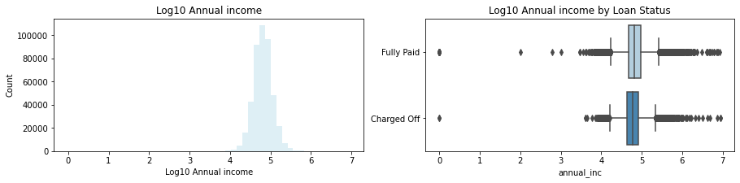

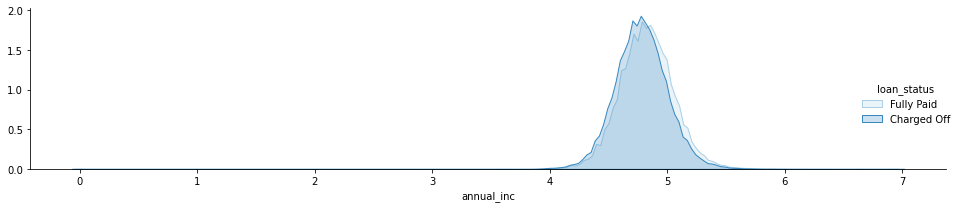

```python
plot_var('annual_inc', 'Log10 Annual income', continua=True)
```

Como era de esperar, hay bastantes outliers en ambos casos.

Además, parece no identificarse una diferencia entre los préstamos pagados y no pagados, según los ingresos del individuo.

## `application_type`

```python
LOAN['application_type'].value_counts()
```

```
Individual    441550
Joint App       1017
Name: application_type, dtype: int64
```

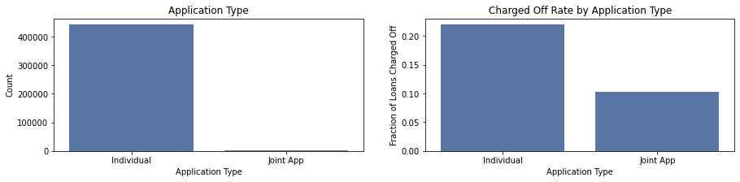

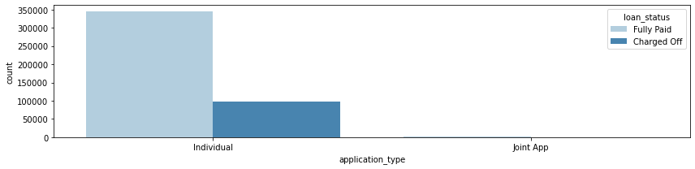

```python
plot_var('application_type', 'Application Type', continua=False)
```

Está bastante desbalanceada esta variable, vemos que la mayoría de los préstamos son individuales y además, estos son los que más probabilidad tienen de ser cancelados.

## `dti`

```python
LOAN['dti'].describe()
```

```
count    442567.000000
mean         18.365975
std           8.726296
min           0.000000
25%          12.060000
50%          17.840000
75%          24.270000
max         999.000000
Name: dti, dtype: float64
```

El valor máximo de 999 no parece normal. De hecho nos descuadra a la hora de representar gráficamente.

```python
LOAN.groupby('loan_status')['dti'].median()
```

```
loan_status
Charged Off    20.28
Fully Paid     17.20
Name: dti, dtype: float64
```

Vemos que los prestatarios con un mayor ratio DTI es más posible que cancelen el préstamo.

## `emp_length`

```python
LOAN['emp_length'].value_counts(normalize=False)
```

```
10+ years    146118
2 years       39568
< 1 year      35725
3 years       35082
1 year        28727
4 years       25906
5 years       25742
0             23874
8 years       22252
7 years       21809
6 years       20087
9 years       17677
Name: emp_length, dtype: int64
```

Trasnformamos las dos clases que contienen algún símbolo más allá de year/s:

```python
LOAN['emp_length'].replace('10+ years', '10 years', inplace=True)
```

```python
LOAN['emp_length'].replace('< 1 year', '0 years', inplace=True)
```

```python
LOAN['emp_length'].value_counts(normalize=False)
```

```
10 years    146118
2 years      39568
0 years      35725
3 years      35082
1 year       28727
4 years      25906
5 years      25742
0            23874
8 years      22252
7 years      21809
6 years      20087
9 years      17677
Name: emp_length, dtype: int64
```

Para poder trabajar con la variable, tenemos que quitarle la parte de year o years:

```python
LOAN.emp_length.map(lambda x: str(x).split()[0]).value_counts(normalize=False)
```

```
10    146118
0      59599
2      39568
3      35082
1      28727
4      25906
5      25742
8      22252
7      21809
6      20087
9      17677
Name: emp_length, dtype: int64
```

Convertimos en float:

```python
LOAN['emp_length'] = LOAN.emp_length.map(lambda x: float(str(x).split()[0]))
```

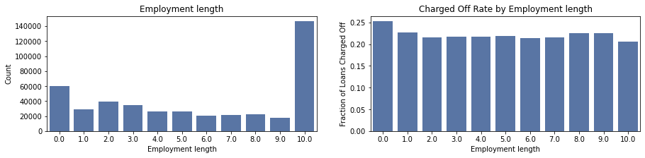

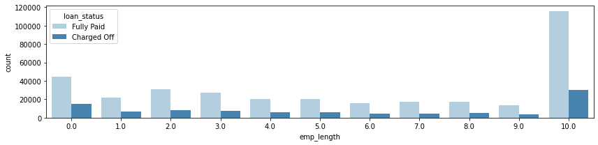

```python
plot_var('emp_length', 'Employment length', continua=False)
```

Además, parece que que se termine pagando o no, no depende, en general, de los años que lleve el individuo trabajando, aunque sí se puede apreciar que, proporcionalmente, aquellos que llevan menos de 1 año trabajando tienen más riesgo de no pagar.

## `grade` & `sub_grade`

```python
sorted(LOAN["grade"].unique())
```

```
['A', 'B', 'C', 'D', 'E', 'F', 'G']
```

```python
sorted(LOAN["sub_grade"].unique())
```

```
['A1',
 'A2',
 'A3',
 'A4',
 'A5',
 'B1',
 'B2',
 'B3',
 'B4',
 'B5',
 'C1',
 'C2',
 'C3',
 'C4',
 'C5',
 'D1',
 'D2',
 'D3',
 'D4',
 'D5',
 'E1',
 'E2',
 'E3',
 'E4',
 'E5',
 'F1',
 'F2',
 'F3',
 'F4',
 'F5',
 'G1',
 'G2',
 'G3',
 'G4',
 'G5']
```

Vemos que los subgrupos contienen a los grupos, por tanto prescindimos de los grupos:

```python
LOAN.drop('grade',axis=1,inplace=True)
```

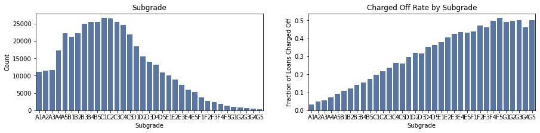

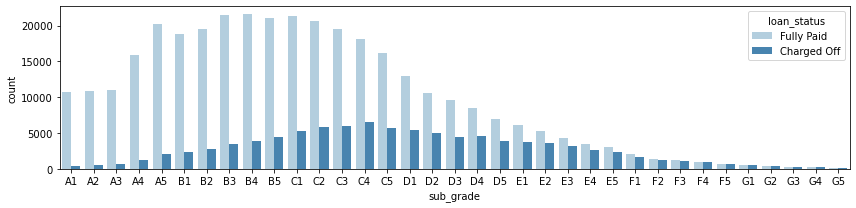

```python
plot_var('sub_grade','Subgrade',continua=False)
```

De los gráficos se desprende que cuanto peor esté calificado el crédito, más impagos se producen, aún siendo estos préstamos los que menos se conceden.

## `home_ownership`

```python
LOAN['home_ownership'].value_counts()
```

```
MORTGAGE    220489
RENT        176094
OWN          45982
ANY              2
Name: home_ownership, dtype: int64
```

Sumamos las dos observaciones de any a OWN, por ejemplo.

```python
LOAN['home_ownership'].replace(['ANY'],'OWN', inplace=True)
```

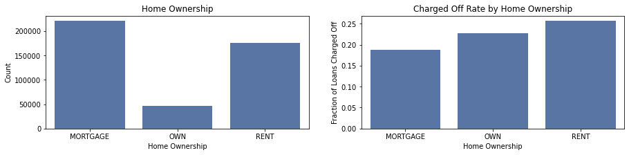

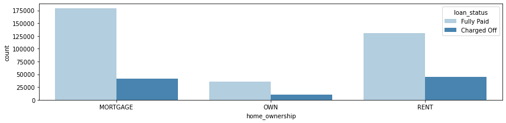

```python
plot_var('home_ownership', 'Home Ownership', continua=False)
```

Observamos que, proporcionalmente, los individuos que tienen más riesgo de no pagar son los que viven de alquiler.

## `initial_list_status`

```python
LOAN['initial_list_status'].value_counts()
```

```
w    249085
f    193482
Name: initial_list_status, dtype: int64
```

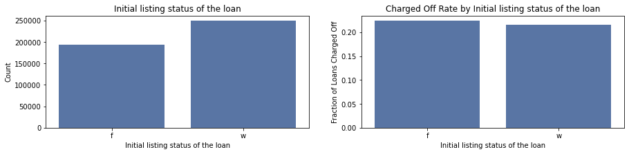

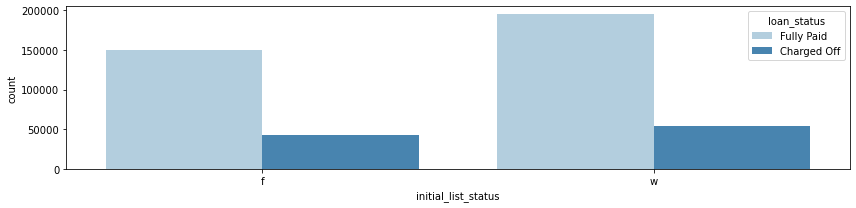

```python
plot_var('initial_list_status','Initial listing status of the loan', continua=False)
```

Parece que no hay diferencias en este caso.

## `installment`

(Pago mensual adeudado por el prestatario si el préstamo se origina)

```python
LOAN['installment'].describe()
```

```
count    442567.000000
mean        439.919579
std         252.533164
min          14.010000
25%         256.900000
50%         378.730000
75%         579.650000
max        1714.540000
Name: installment, dtype: float64
```

Vemos que de media los pagos mensuales suelen ser de 400 dólares aproximadamente, estando los mínimos en 14 dólares y la cantidad máxima en 1.715 dólares.

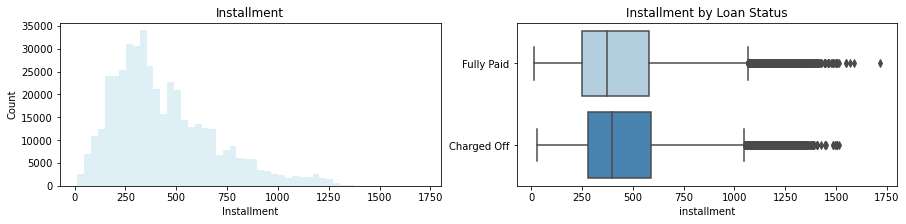

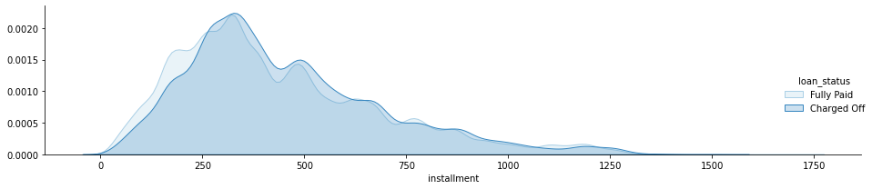

```python
plot_var('installment', 'Installment', continua=True)
```

Tras ver que no existe demasiada diferencia entre las observaciones pagadas y no pagadas respecto a esta variable, procedemos a **eliminarla**:

```python
LOAN.drop("installment", axis=1, inplace=True)
```

```python
LOAN.shape
```

```
(442567, 20)
```

## `int_rate`

```python
LOAN['int_rate'].describe()
```

```
count    442567.000000
mean         13.256698
std           4.471252
min           5.320000
25%           9.990000
50%          12.990000
75%          15.990000
max          30.990000
Name: int_rate, dtype: float64
```

Vemos que los tipos de interés van desde el 5% hasta el 30% aproximadamente, siendo la media de entorno al 13%.

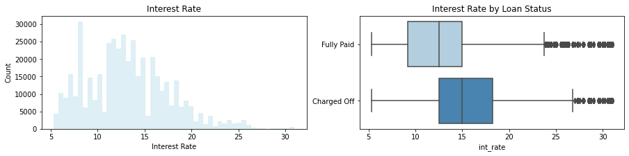

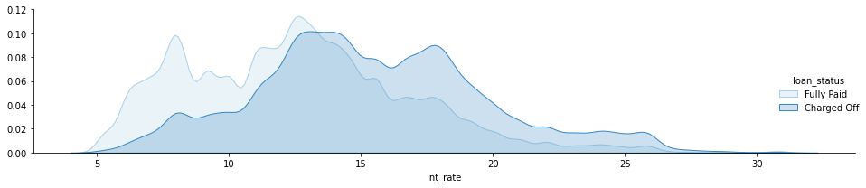

```python
plot_var('int_rate', 'Interest Rate', continua=True)
```

De los gráficos se desprende que, en media, los préstamos que se pagan tienen menores tasas de interés frente a los que no.

## `loan_amnt`

```python
LOAN['loan_amnt'].describe()
```

```
count    442567.000000
mean      14565.650173
std        8500.731901
min        1000.000000
25%        8000.000000
50%       12500.000000
75%       20000.000000
max       40000.000000
Name: loan_amnt, dtype: float64
```

Vemos que la cantidad de los préstamos va desde los 1.000 dólares hasta los 40.000, estando la media entorno a las 14.500 $.

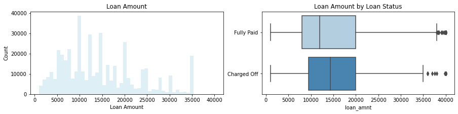

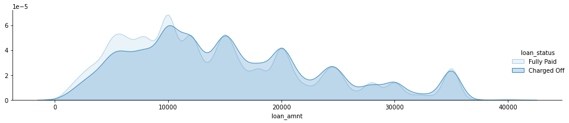

```python
plot_var('loan_amnt', 'Loan Amount', continua=True)
```

En la gráfica boxplot podemos ver que, en media, los préstamos totalmente pagados son de menor importe.

## `mort_acc`

```python
LOAN['mort_acc'].describe()
```

```
count    442567.000000
mean          1.776328
std           2.089754
min           0.000000
25%           0.000000
50%           1.000000
75%           3.000000
max          47.000000
Name: mort_acc, dtype: float64
```

```python
LOAN.mort_acc = LOAN.mort_acc.map(lambda x: 6.0 if x > 6.0 else x)
```

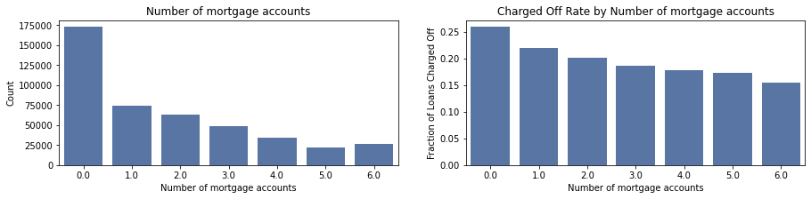

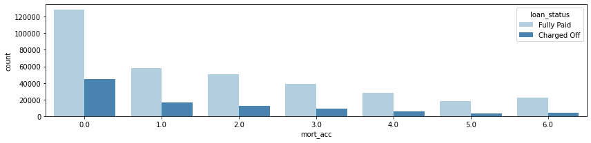

```python
plot_var('mort_acc', 'Number of mortgage accounts', continua=False)
```

Vemos que la mayoría de los individuos no tienen otras hipotecas.

Además se observa que cuantas más hipotecas tenga el prestatario, menos posibilidades hay de impago.

## `open_acc`

```python
LOAN['open_acc'].describe()
```

```
count    442567.000000
mean         11.796530
std           5.458209
min           0.000000
25%           8.000000
50%          11.000000
75%          15.000000
max          90.000000
Name: open_acc, dtype: float64
```

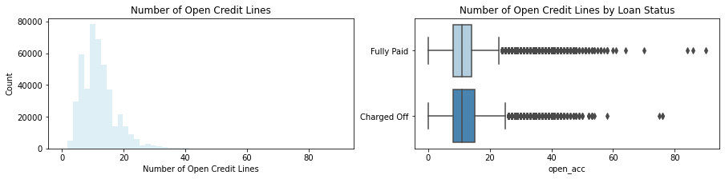

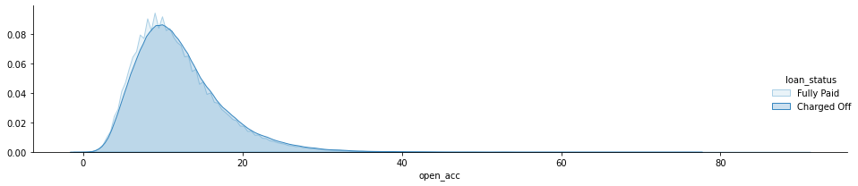

```python
plot_var('open_acc', 'Number of Open Credit Lines', continua=True)
```

Aparentemente no hay una diferencia clara entre los individuos que acaban cancelando o no el préstamo, teniendo en cuenta el número de líneas de crédito abiertas.

## `pub_rec_bankruptcies`

(Quiebras registradas públicamente)

```python
LOAN['pub_rec_bankruptcies'].value_counts()
```

```
0.0     382329
1.0      56299
2.0       3083
3.0        621
4.0        148
5.0         55
6.0         15
7.0         13
8.0          2
12.0         1
9.0          1
Name: pub_rec_bankruptcies, dtype: int64
```

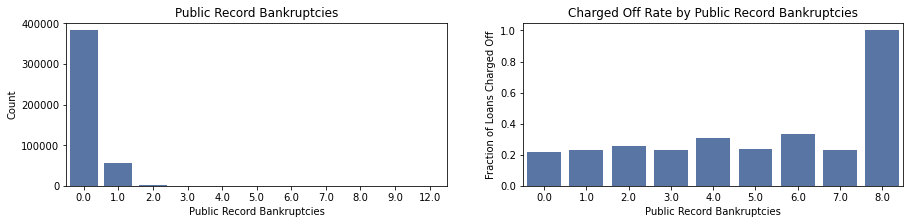

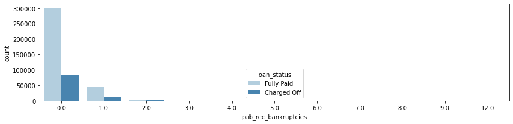

```python
plot_var('pub_rec_bankruptcies', 'Public Record Bankruptcies', continua=False)
```

Vemos que la mayoría de individuos no tiene quibras registradas o tiene 1.

Tiene sentido que a una persona que un nº alto de quiebras registradas no se le conceda un crédito.

## `purpose`

```python
LOAN['purpose'].value_counts()
```

```
debt_consolidation    268151
credit_card            99463
home_improvement       26380
other                  20965
major_purchase          7852
medical                 4548
small_business          4046
car                     3761
moving                  2811
vacation                2603
house                   1717
renewable_energy         258
wedding                   11
educational                1
Name: purpose, dtype: int64
```

Vemos el porcentaje de cancelaciones en cada caso:

```python
LOAN.groupby('purpose')['loan_status'].value_counts(normalize=True)[:,'Charged Off'].sort_values(ascending=False)
```

```
purpose
small_business        0.322541
renewable_energy      0.275194
moving                0.268588
house                 0.252184
medical               0.231970
debt_consolidation    0.230754
other                 0.226377
major_purchase        0.211666
vacation              0.205148
home_improvement      0.195262
credit_card           0.189146
car                   0.171497
Name: loan_status, dtype: float64
```

Vemos que los préstamos que se piden para negocios pequeños tienen un 33% de cancelación, seguidos de los préstamos relacionados con energías renovables, traslados, para el hogar o salud entre otros.

Los préstamos que menor riesgo de cancelación tienen son los que se piden para pagar coches.

Para ver la relación entre la **cantidad de préstamo solicitado y el porqué**:

```python
purpose = LOAN[['purpose', 'loan_amnt']].groupby('purpose', as_index = False).sum().sort_values('loan_amnt', ascending = False)
total_loan = purpose['loan_amnt'].sum()
purpose['% de la cantidad del préstamo'] = purpose['loan_amnt'].map(lambda x: '{:.2f}'.format(100 * x / total_loan)).astype('float')
```

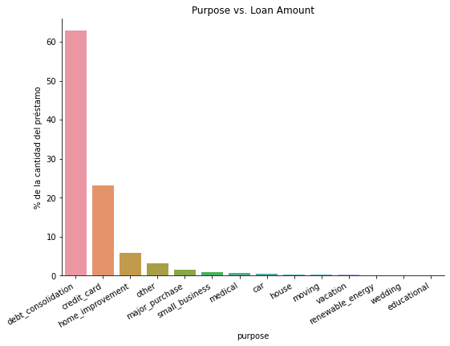

```python
sns.catplot(x = "purpose", y = "% de la cantidad del préstamo",kind = 'bar', aspect=1.5, data = purpose).set_xticklabels(rotation=30, ha='right')
plt.title('Purpose vs. Loan Amount')
plt.show()
```

Observamos que más del 60% de los préstamos se piden para la consolidación de deudas, seguidos de lejos por credit card (algo más del 20%).

## `revol_bal`

```python
LOAN['revol_bal'].describe()
```

```
count    4.425670e+05
mean     1.629687e+04
std      2.232927e+04
min      0.000000e+00
25%      5.987000e+03
50%      1.115000e+04
75%      1.985500e+04
max      2.560703e+06
Name: revol_bal, dtype: float64
```

Lo convertimos a escala logarítmica:

```python
LOAN['revol_bal'] = LOAN['revol_bal'].apply(lambda x:np.log10(x+1))
```

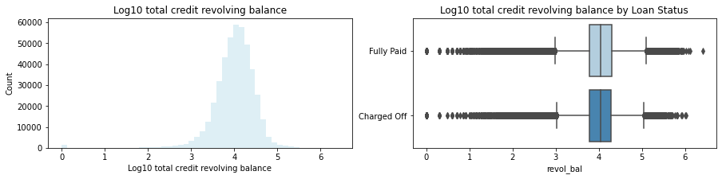

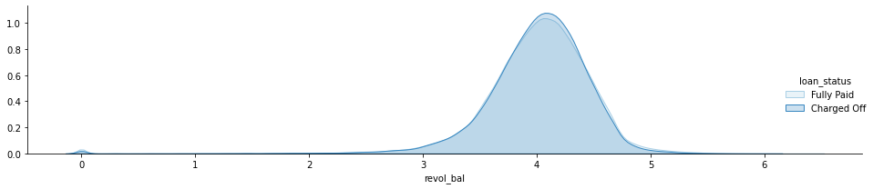

```python
plot_var('revol_bal', 'Log10 total credit revolving balance', continua=True)
```

No hay diferencias.

## `revol_util`

```python
LOAN['revol_util'].describe().round(2)
```

```
count    442567.00
mean         53.09
std          23.84
min           0.00
25%          35.40
50%          53.40
75%          71.30
max         892.30
Name: revol_util, dtype: float64
```

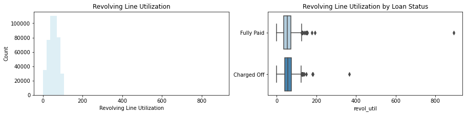

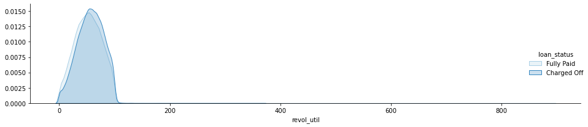

```python
plot_var('revol_util', 'Revolving Line Utilization', continua=True)
```

Los outliers afectan en la representación gráfica, de todas formas, no se aprecian diferencias.

## `term`

```python
LOAN['term'].value_counts(normalize=True)
```

```
 36 months    0.744174
 60 months    0.255826
Name: term, dtype: float64
```

Vemos que el 75% de las observaciones son préstamos a 36 meses, es decir, 3 años, mientras que el otro 25% aproximadamente, son préstamos a 60 meses, es decir, 5 años.

Haremos una transformación para representar los datos según la función que hemos definido al inicio:

```python
LOAN['term'] = LOAN['term'].apply(lambda x: np.int8(x.split()[0]))
```

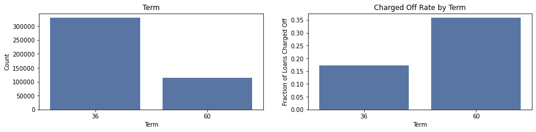

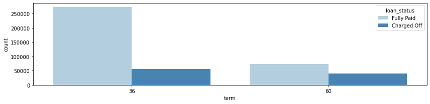

```python
plot_var('term', 'Term', continua=False)
```

De las gráficas podemos concluir principalmente que:

[output not shown]

## `total_acc`

```python
LOAN['total_acc'].describe()
```

```
count    442567.000000
mean         26.035520
std          12.158434
min           2.000000
25%          17.000000
50%          24.000000
75%          33.000000
max         169.000000
Name: total_acc, dtype: float64
```

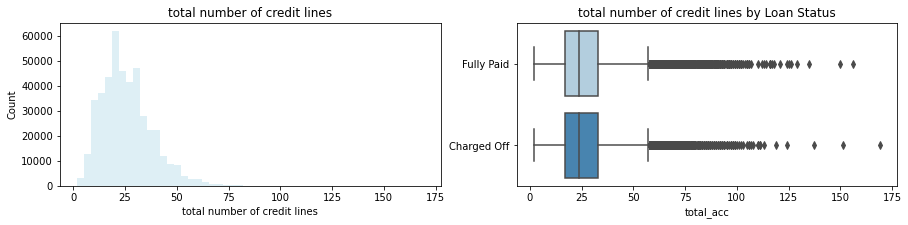

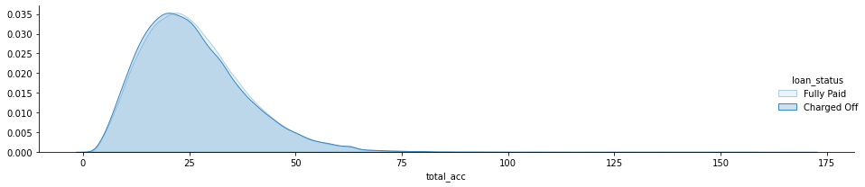

```python
plot_var('total_acc', 'total number of credit lines', continua=True)
```

No se aprecian diferencias.

## `verification_status`

```python
LOAN['verification_status'].value_counts()
```

```
Source Verified    181936
Not Verified       131307
Verified           129324
Name: verification_status, dtype: int64
```

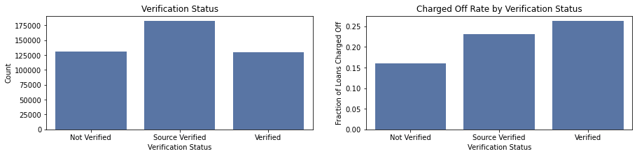

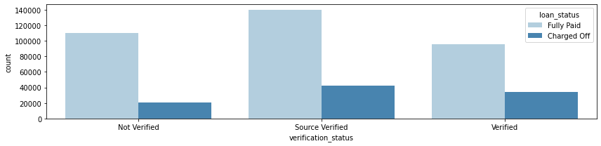

```python
plot_var('verification_status', 'Verification Status', continua=False)
```

Observamos que los préstamos 'Verificados' tienen más posibilidades de impago frente a los no verificados.

## Matriz de correlación

```python
LOAN.to_csv('../data/raw/LOAN.csv', index=True)
```

```python
variables_numericas = LOAN.select_dtypes(include = [np.number])
```

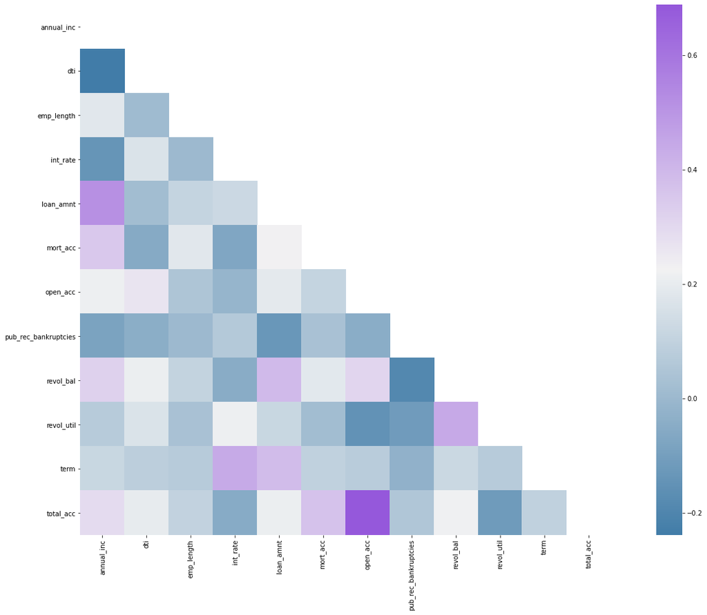

```python
corr = variables_numericas.corr()
mask = np.zeros_like(corr)
mask[np.triu_indices_from(mask)] = True
cmap = sns.diverging_palette(600, 1000, as_cmap=True)
ax = sns.heatmap(corr, cmap=cmap,
xticklabels=corr.columns.values,
yticklabels=corr.columns.values,
square = True,mask = mask)
plt.gcf().set_size_inches(25,15)
plt.show()
```

Vemos que las variables `total_acc` y `open_acc` están muy correlacionadas, lo cual tiene sentido.

El `loan_amnt`está bastante relacionado con el `annual_inc`, lo cual también tiene sentido.

Se ve algo de correlación en `revol_util` y `revol_bal`también.

## Guardamos el csv tras las modificaciones

```python
LOAN.head()
```

|  | addr_state | annual_inc | application_type | dti | emp_length | home_ownership | initial_list_status | int_rate | loan_amnt | mort_acc | open_acc | pub_rec_bankruptcies | purpose | revol_bal | revol_util | sub_grade | term | total_acc | verification_status | loan_status |
| --- | --- | --- | --- | --- | --- | --- | --- | --- | --- | --- | --- | --- | --- | --- | --- | --- | --- | --- | --- | --- |
| 8 | CA | 5.184694 | Individual | 16.99 | 6.0 | OWN | w | 7.35 | 11575.0 | 2.0 | 20.0 | 1.0 | credit_card | 3.932017 | 22.7 | A4 | 36 | 46.0 | Not Verified | Fully Paid |
| 10 | WA | 4.698979 | Individual | 6.07 | 2.0 | RENT | w | 24.85 | 7200.0 | 0.0 | 4.0 | 0.0 | debt_consolidation | 3.551572 | 98.9 | E3 | 36 | 5.0 | Source Verified | Fully Paid |
| 24 | TX | 5.041397 | Individual | 13.12 | 7.0 | MORTGAGE | w | 7.35 | 7500.0 | 4.0 | 19.0 | 0.0 | debt_consolidation | 4.368268 | 27.2 | A4 | 36 | 27.0 | Not Verified | Fully Paid |
| 42 | CA | 4.715836 | Individual | 10.11 | 7.0 | RENT | w | 16.02 | 10000.0 | 0.0 | 15.0 | 2.0 | debt_consolidation | 3.758458 | 20.0 | C5 | 60 | 21.0 | Source Verified | Fully Paid |
| 91 | MA | 4.875067 | Individual | 10.86 | 7.0 | MORTGAGE | w | 16.02 | 14000.0 | 1.0 | 4.0 | 0.0 | debt_consolidation | 3.431525 | 90.0 | C5 | 36 | 10.0 | Verified | Fully Paid |

```python
LOAN.to_csv('../data/intermediate/LOAN.csv', index=False)
```